# Hate in Context

Week 1: Introduction and Defining Hate Crime

Violeta Haas

Department of Political Science

School of Social Sciences and Philosophy

Trinity College Dublin

# Today

1. Welcome
2. Practicalities
3. Assessment
4. Course Content
5. Questions

# Welcome!

## Hi! 👋

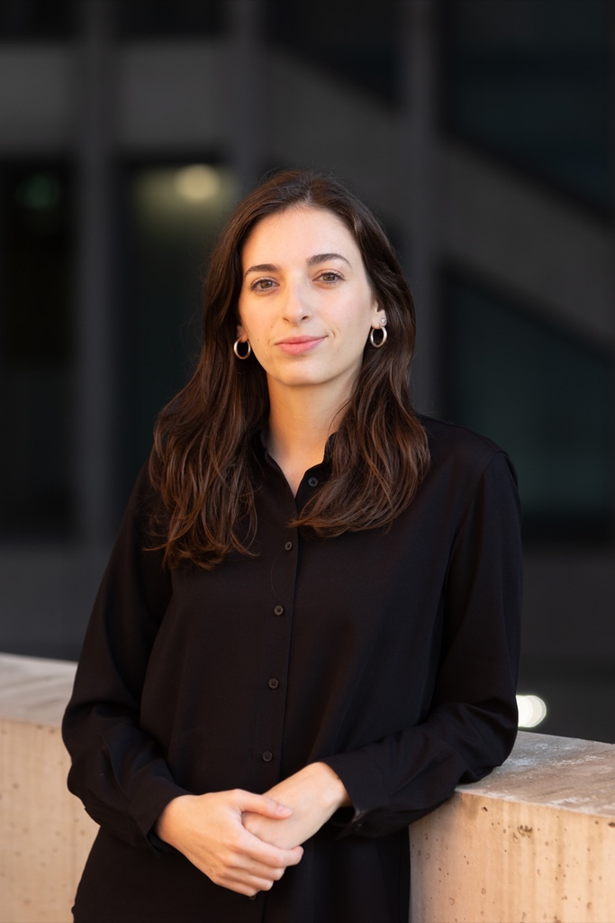

**Violeta Haas**  
Assistant Professor in Political Science  
New at Trinity College Dublin

**Previously**

- Postdoc, IAST / Toulouse School of Economics
- PhD, DYNAMICS (Humboldt-Universität zu Berlin, 2024)

**Research**

How institutions and elites shape perceptions of and behaviour toward marginalized groups (esp. immigration & LGBTQ+ rights). Also party competition, social norms, and protest.

**Methods**

Causal identification & computational social science. Experiments plus multimodal LLM applications.

## How to reach me

- **General questions:** Blackboard → General Questions discussion forum  
  (things that may interest others too, such as deadlines, readings, logistics)
- **Individual questions:** violeta.haas@tcd.ie. You can also approach me after class  
  (personal circumstances, grades, anything sensitive)
- **Office hours:** by appointment

Feedback, criticism, and suggestions always welcome

**Note**

Please check both Blackboard and your Trinity email regularly.

## Your turn

Quick round. Share:

- Name
- Programme
- How long your commute was
- One thing you’re hoping to get from this module

# Practicalities

## When and where

| Day | Time | Room |
| --- | --- | --- |
| **Monday** | 12–1 pm | 1A, Goldsmith Hall |
| **Wednesday** | 11–12 pm | 1.16, Foster Place |

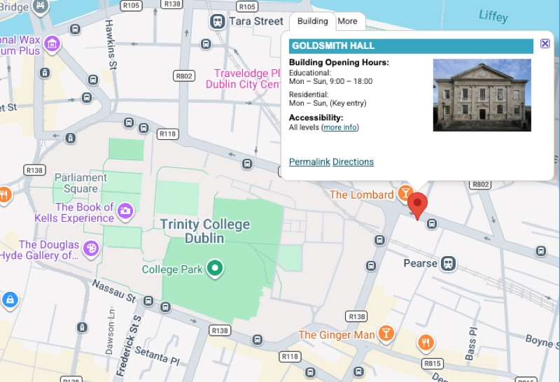

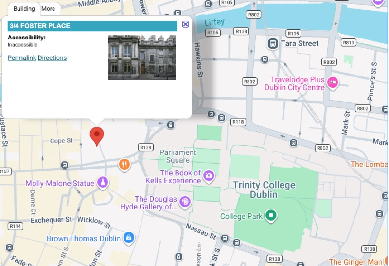

## Classroom norms

- First-name basis?
- If personal circumstances make requirements hard to meet, contact me
- Arrive on time so we can use the full 50 minutes
- Cameras on for Zoom office hours or guest sessions, please

## Discussion norms

- Uncertainty and imperfect takes are welcome. Say where you’re unsure
- Ask questions early rather than sitting with confusion
- Disagree with arguments and evidence, not with people
- Build on others’ points and acknowledge them
- One voice at a time. Leave space for quieter classmates

## Discussing sensitive material

- Use careful, scholarly language when discussing hate speech and targets of violence
- If something lands badly, say so. We can pause and restart

**Note**

**Content warning:** This module examines the causes, consequences and responses to bias-motivated behavior. Materials may include descriptions of hate crimes, hate speech, and other disturbing or offensive content (including racist, antisemitic, Islamophobic, anti-LGBTQ+, and similarly hateful language or imagery).

# Assessment

## Three components

| Component | Weight | Core idea |
| --- | --- | --- |
| Participation | **30%** | Weekly Comments + attendance + seminar engagement |
| Position paper | **10%** | Express and defend an opinion based on the readings |
| Research proposal | **60%** | Propose an empirical study |

## Participation (30%)

1. **Weekly comments (150–250 words)**, due **Sunday 11:59 pm**
   - Focus on required readings
   - Critique, question, or reflect. Do not summarise.
   - No comment in Week 1, Reading Week, or your position-paper week
   - Two additional jokers
   - Week 11: Guest lecturer paper comments cannot be skipped
2. **Attendance:** regular & prepared
3. **In-seminar contributions**

## Position paper (10%)

- **800–1,200 words** on one week’s readings
- Defend a position: (dis)agree with key arguments, usefulness for current politics, or take sides when papers conflict
- Due **Sunday 11:59 pm** before that week’s Monday seminar
- Replaces the weekly comment that week

**Sign up**

**Blackboard → Groups**. Choose one week (max 3 students per week).

Opens: **Mon 14 Sep, 1:00 pm**  
Closes: **Fri 18 Sep, 11:59 pm**.

## Research proposal (60%)

A proposal for an empirical study (**2,500–3,000 words**):

1. Clear research question
2. Critical literature synthesis
3. Theoretical argument
4. Empirical approach (cases, methods, data)

**Sign up**

Book a **15-minute** office hour (in person or Zoom) in the **two weeks after Reading Week** to discuss your topic.

You do **not** need to carry out the full study. Deadline: Fri 11 Dec, 11:59 pm.

## Written work

- Stay within word limits (references / captions don’t count)
- PDF, double-spaced, 12pt
- Consistent citation style + bibliography
- Research proposal: short end note on gender share of cited authors (e.g. for this syllabus: Cited authors: 37% women among all authors; 44% women among first authors. About 60% of readings include at least one woman. Reflection only, not graded.)

**Note**

Useful resources: [Academic Style Guides](https://www.tcd.ie/library/assets/pdf/Academic%20Style%20Guides.pdf)

## Late work and extensions

Late Submission of Assessments (Extensions) Policy

- Late work without approved extension: **5 points per day** (including weekends)
- More than **five days** late without approval: may not be marked
- Once work has been marked and returned to others: late submissions get 0
- Request extensions for extenuating circumstances **before the deadline**

**LENS (flexible deadlines)**

If your LENS includes flexible assessment deadlines, you get a default **one-week** extension on eligible written work where practical.

- **Position paper and research proposal:** applies automatically
- **Weekly comments:** not practical (read before Monday). You get an **extra joker** instead. Contact me if you need another arrangement.

Useful Resources: [Trinity Disability Service](https://www.tcd.ie/disability/)

## Academic integrity and plagiarism

- All submitted work must be your own, plagiarism of any kind will be sanctioned:
  - unacknowledged quotation or paraphrase
  - self-plagiarism (e.g. reusing work from another module)
  - ghostwriting
  - presenting AI text as your own unassisted work

Academic dishonesty can mean no credit for an assignment, a failing grade for the module, or further College sanctions

**Note**

Useful resources: [Academic integrity](https://libguides.tcd.ie/academic-integrity) & [Ready Steady Write](https://libguides.tcd.ie/academic-integrity/ready-steady-write)

## Generative AI

- Core ideas, arguments, text, and references must be **yours**
- AI in class only if explicitly allowed
- Direct paste of AI text: never
- Comments: research/learning help OK
- Paper / proposal: research + writing help OK if you revise and fact-check

Disclose AI use on the School submission form

**Note**

Useful resources: [Library GenAI resources](https://libguides.tcd.ie/gen-ai) & [College GenAI hub](https://www.tcd.ie/academicpractice/resources/gen-ai-hub/). As TCD students, you can log in at [copilot.cloud.microsoft](https://copilot.cloud.microsoft/) with your Trinity account and use Copilot there.

# Course Content

## Course roadmap

Causes Weeks 2–6 Demographic change  
Economic conditions  
(Social) media  
Threatening events  
Political elites

Consequences Week 8 Community impacts

Responses Weeks 9–10 Contact  
Persuasion

Guest lecture Week 11 Inclusionary policy  
Exclusionary policy

Your choice Week 12 Propose topic by  
Fri 23 Oct, 11:59 pm

## How to read for this seminar

When preparing a paper, try to identify:

1. Research question
2. What is explained (**Y**)
3. Main explanatory factor (**X**)
4. Central concepts
5. Methods / research design
6. Main findings
7. Real-world implications
8. Contribution to the literature
9. Critique and limitations

**Note**

Useful resource: [Macartan Humphreys, How to read](https://macartan.github.io/teaching/how-to-read)

## Week 1

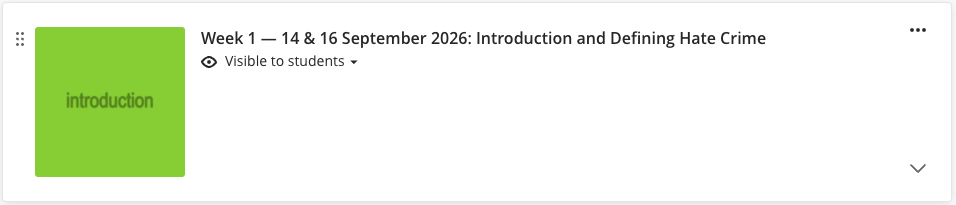

**Additional readings** (no required reading this week)

- Dancygier, R. M., & Green, D. P. (2011). Hate crime. In J. F. Dovidio, M. Hewstone, P. Glick, & V. M. Esses (Eds.), *The SAGE handbook of prejudice, stereotyping and discrimination* (pp. 294–311). Sage.
- Schweppe, J. (2021). What is a hate crime? *Cogent Social Sciences*, 7(1), Article 1902643.
- Chakraborti, N. (2014). Framing the boundaries of hate crime. In N. Hall, A. Corb, P. Giannasi, & J. Grieve (Eds.), *The Routledge international handbook on hate crime* (pp. 13–23). Routledge.
- Vergani, M., Perry, B., Freilich, J., Chermak, S., Scrivens, R., Link, R., Kleinsman, D., Betts, J., & Iqbal, M. (2024). Mapping the scientific knowledge and approaches to defining and measuring hate crime, hate speech, and hate incidents: A systematic review. *Campbell Systematic Reviews*, 20(2), Article e1397.

## Week 2

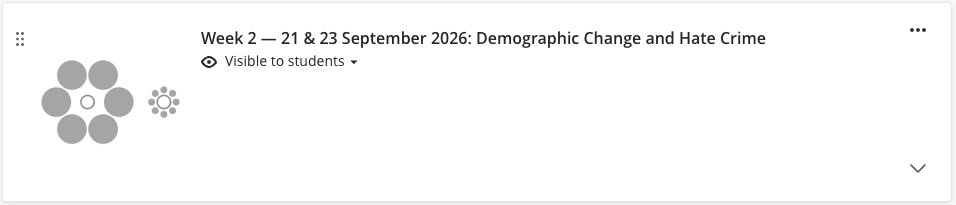

**Required**

- Cikara, M., Fouka, V., & Tabellini, M. (2022). Hate crime towards minoritized groups increases as they increase in size-based rank. *Nature Human Behaviour*, 6(11), 1537–1544.
- Hangartner, D., Dinas, E., Marbach, M., Matakos, K., & Xefteris, D. (2019). Does exposure to the refugee crisis make natives more hostile? *American Political Science Review*, 113(2), 442–455.
- Dancygier, R., Egami, N., Jamal, A., & Rischke, R. (2022). Hate crimes and gender imbalances: Fears over mate competition and violence against refugees. *American Journal of Political Science*, 66(2), 501–515.

## Week 3

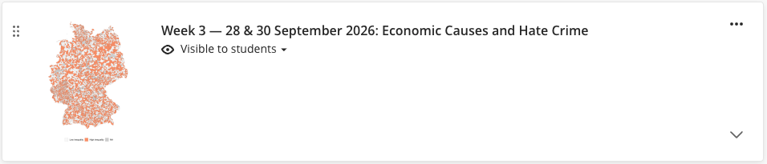

**Required**

- Riaz, S. (2023). Does inequality foster xenophobia? Evidence from the German refugee crisis. *Journal of Ethnic and Migration Studies*, 50(2), 359–378.
- Bestenbostel, A., & Peralta, A. (2026). WARNings: The impact of negative economic news on racial animus. *Journal of Economic Behavior & Organization*, 243, Article 107399.

## Week 4

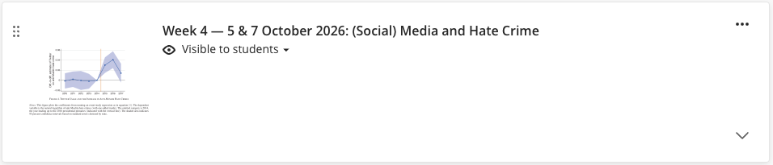

**Required**

- Siegel, A. A. (2020). Online hate speech. In N. Persily & J. A. Tucker (Eds.), *Social media and democracy: The state of the field, prospects for reform* (pp. 56–88). Cambridge University Press.
- Müller, K., & Schwarz, C. (2023). From hashtag to hate crime: Twitter and antiminority sentiment. *American Economic Journal: Applied Economics*, 15(3), 270–312.

## Week 5

[figure not shown]

**Required**

- Dipoppa, G., Grossman, G., & Zonszein, S. (2023). Locked down, lashing out: COVID-19 effects on Asian hate crimes in Italy. *The Journal of Politics*, 85(2), 389–404.
- Riaz, S., Bischof, D., & Wagner, M. (2024). Out-group threat and xenophobic hate crimes: Evidence of local intergroup conflict dynamics between immigrants and natives. *The Journal of Politics*, 86(4), 1146–1161.
- Álvarez-Benjumea, A., & Winter, F. (2020). The breakdown of antiracist norms: A natural experiment on hate speech after terrorist attacks. *Proceedings of the National Academy of Sciences*, 117(37), 22800–22804.

## Week 6

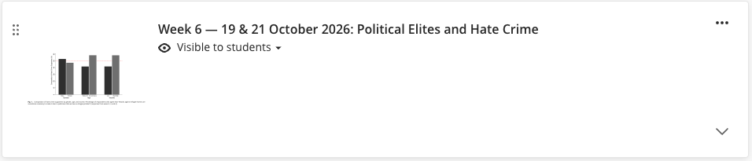

**Required**

- Romarri, A. (2020). Do far-right mayors increase the probability of hate crime? Evidence from Italy. Working paper.
- Dancygier, R. (2023). Hate crime supporters are found across age, gender, and income groups and are susceptible to violent political appeals. *Proceedings of the National Academy of Sciences*, 120(7), Article e2212757120.
- Zonszein, S., & Grossman, G. (2025). Voted in, standing out: Public response to immigrants’ political accession. *American Journal of Political Science*, 69(2), 718–733.

## Week 7

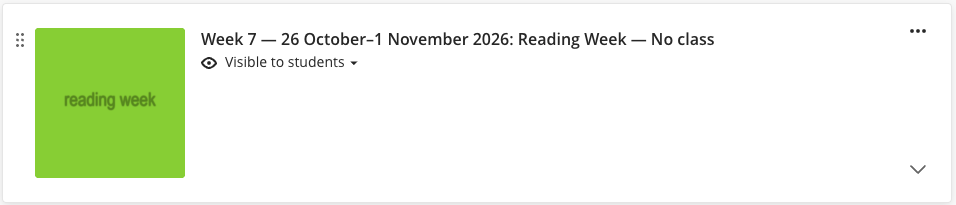

**No class.** Use the week for catching up on readings and developing research-proposal ideas.

## Week 8

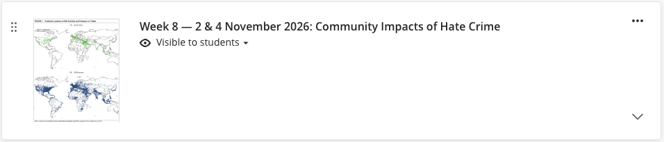

**Required**

- Mitts, T. (2019). From isolation to radicalization: Anti-Muslim hostility and support for ISIS in the West. *American Political Science Review*, 113(1), 173–194.
- Branton, R., & Kropf, M. (2026). Mail voting as a tool to avoid voter intimidation and hate crimes. *American Politics Research*, 54(4), 400–410.
- Roman, M. F., & Thompson, J. (2024). Fickle prosociality: How violence against LGBTQ+ people motivates prosocial mass attitudes toward LGBTQ+ group members. *American Political Science Review*, 119(4), 1665–1683.

## Week 9

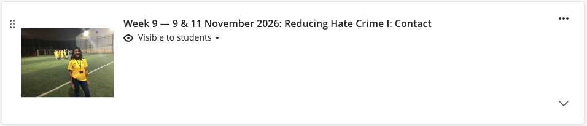

**Required**

- Scope Conditions. (n.d.). The promise and limits of intergroup contact, with Salma Mousa [Audio podcast episode]. *Scope Conditions Podcast*. [scopeconditionspodcast.com](https://www.scopeconditionspodcast.com/episodes/episode-01salmamousa).
- Alrababa’h, A., Marble, W., Mousa, S., & Siegel, A. A. (2021). Can exposure to celebrities reduce prejudice? The effect of Mohamed Salah on Islamophobic behaviors and attitudes. *American Political Science Review*, 115(4), 1111–1128.
- Mousa, S. (2020). Building social cohesion between Christians and Muslims through soccer in post-ISIS Iraq. *Science*, 369(6505), 866–870.
- Scacco, A., & Warren, S. S. (2018). Can social contact reduce prejudice and discrimination? Evidence from a field experiment in Nigeria. *American Political Science Review*, 112(3), 654–677.

## Week 10

[figure not shown]

**Required**

- Broockman, D., & Kalla, J. (2016). Durably reducing transphobia: A field experiment on door-to-door canvassing. *Science*, 352(6282), 220–224.
- Adida, C. L., Lo, A., & Platas, M. R. (2018). Perspective taking can promote short-term inclusionary behavior toward Syrian refugees. *Proceedings of the National Academy of Sciences*, 115(38), 9521–9526.
- Hangartner, D., Gennaro, G., Alasiri, S., Bahrich, N., Bornhoft, A., Boucher, J., et al. (2021). Empathy-based counterspeech can reduce racist hate speech in a social media field experiment. *Proceedings of the National Academy of Sciences*, 118(50), Article e2116310118.
- Kalla, J. L., & Broockman, D. E. (2020). Reducing exclusionary attitudes through interpersonal conversation: Evidence from three field experiments. *American Political Science Review*, 114(2), 410–425.
- Kalla, J. L., & Broockman, D. E. (2023). Which narrative strategies durably reduce prejudice? Evidence from field and survey experiments supporting the efficacy of perspective-getting. *American Journal of Political Science*, 67(1), 185–204.

## Week 11

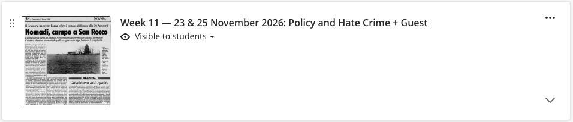

**Required**

- Lehmann, M. C., & Masterson, D. T. (2020). Does aid reduce anti-refugee violence? Evidence from Syrian refugees in Lebanon. *American Political Science Review*, 114(4), 1335–1342.
- Levy, B. L., & Levy, D. L. (2017). When love meets hate: The relationship between state policies on gay and lesbian rights and hate crime incidence. *Social Science Research*, 61, 142–159.
- Allinger, T. L. (n.d.). Do exclusionary policies increase hate crimes? Evidence from the nomad camps in Italy. Working paper.

## Week 12

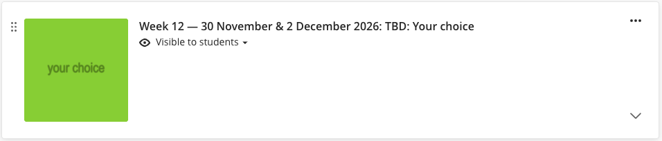

Post topic ideas to the Blackboard Discussion forum by **Fri 23 Oct, 11:59 pm**.

## Important dates

| Position-paper sign-up closes | Fri 18 Sep, 11:59 pm |
| --- | --- |
| Position paper due | one Sunday 11:59 pm |
| Weekly comments due | each Sunday, 11:59 pm |
| Week 12 topic ideas due | Fri 23 Oct, 11:59 pm |
| Office-hour sign-up (proposal topic) | Fri 30 Oct, 11:59 pm |
| Reading Week (no class) | 26 Oct – 1 Nov |
| Guest lecture (Allinger) | Wed 25 Nov |
| Research proposal due | Fri 11 Dec, 11:59 pm |

# Questions?

# Goodbye!

See you on Wednesday.